# Assignment SQL

Author

Fatoumatta Demba

### Part I: Answer the following question by running SQL using **RStudio**.

#### a.

List the first **10 rows** of the `flights` table.

```r
dbGetQuery(conn, "
  SELECT *
  FROM flights
  LIMIT 10
")
```

```
   year month day dep_time sched_dep_time dep_delay arr_time sched_arr_time
1  2013     1   1      517            515         2      830            819
2  2013     1   1      533            529         4      850            830
3  2013     1   1      542            540         2      923            850
4  2013     1   1      544            545        -1     1004           1022
5  2013     1   1      554            600        -6      812            837
6  2013     1   1      554            558        -4      740            728
7  2013     1   1      555            600        -5      913            854
8  2013     1   1      557            600        -3      709            723
9  2013     1   1      557            600        -3      838            846
10 2013     1   1      558            600        -2      753            745
   arr_delay carrier flight tailnum origin dest air_time distance hour minute
1         11      UA   1545  N14228    EWR  IAH      227     1400    5     15
2         20      UA   1714  N24211    LGA  IAH      227     1416    5     29
3         33      AA   1141  N619AA    JFK  MIA      160     1089    5     40
```

[output cut: 18 more lines]

This query displays the first 10 rows of the flights table. The SELECT * statement retrieves all the columns in the table, including information about the flight date, departure time, arrival time, delays, and airports. The FROM flights statement specifies which table to retrieve the information from, while LIMIT 10 restricts the output to 10 rows.

#### b.

Find the **number of flights**

1. in the dataset

```r
dbGetQuery(conn, "
  SELECT COUNT(*) AS number_of_flights
  FROM flights
")
```

```
  number_of_flights
1            336776
```

1. for each carrier

```r
dbGetQuery(conn, "
  SELECT carrier, COUNT(*) AS number_of_flights
  FROM flights
  GROUP BY carrier
  ORDER BY number_of_flights DESC
")
```

```
   carrier number_of_flights
1       UA             58665
2       B6             54635
3       EV             54173
4       DL             48110
5       AA             32729
6       MQ             26397
7       US             20536
8       9E             18460
9       WN             12275
10      VX              5162
11      FL              3260
12      AS               714
13      F9               685
14      YV               601
15      HA               342
16      OO                32
```

This query calculates the total number of records in the flights table. The COUNT(*) function counts every row in the table, with each row representing a flight record. The AS number_of_flights statement gives the resulting column a descriptive name, making the output easier to understand. This query provides an overall count of the flights included in the dataset.

#### c.

Find the **average departure delay** (`dep_delay`)

```r
dbGetQuery(conn, "
  SELECT AVG(dep_delay) AS average_departure_delay
  FROM flights
")
```

```
  average_departure_delay
1                12.63907
```

This query calculates the average departure delay across all flights in the dataset. The AVG(dep_delay) function calculates the mean of the values in the dep_delay column, which records how many minutes a flight departed early or late. Positive values indicate delays, while negative values indicate departures earlier than scheduled. The AS average_departure_delay statement gives the result a descriptive column name.

#### d.

Find the **top 5 destinations** (`dest`) With the most flights.

- Your output should include:
  - destination
  - number of flights Sort from the **largest to smallest**.

```r
dbGetQuery(conn, "
  SELECT dest, COUNT(*) AS number_of_flights
  FROM flights
  GROUP BY dest
  ORDER BY number_of_flights DESC
  LIMIT 5
")
```

```
  dest number_of_flights
1  ORD             17283
2  ATL             17215
3  LAX             16174
4  BOS             15508
5  MCO             14082
```

This query identifies the five destinations that received the most flights in the dataset. The SELECT dest statement specifies the destination airport code, while COUNT(*) counts the number of flight records associated with each destination. The GROUP BY dest statement groups flights going to the same destination together. The ORDER BY number_of_flights DESC statement sorts destinations from the highest flight count to the lowest, and LIMIT 5 returns only the top five destinations.

#### e.

Create a table showing:

- `carrier`
- average arrival delay (`arr_delay`)

Sort the results from **largest to smallest delay**

```r
dbGetQuery(conn, "
  SELECT carrier, AVG(arr_delay) AS average_arrival_delay
  FROM flights
  GROUP BY carrier
  ORDER BY average_arrival_delay DESC
")
```

```
   carrier average_arrival_delay
1       F9            21.9207048
2       FL            20.1159055
3       EV            15.7964311
4       YV            15.5569853
5       OO            11.9310345
6       MQ            10.7747334
7       WN             9.6491199
8       B6             9.4579733
9       9E             7.3796692
10      UA             3.5580111
11      US             2.1295951
12      VX             1.7644644
13      DL             1.6443409
14      AA             0.3642909
15      HA            -6.9152047
16      AS            -9.9308886
```

This query calculates the average arrival delay for each airline carrier. The SELECT carrier statement identifies the airline, and AVG(arr_delay) calculates the mean arrival delay for its flights. The GROUP BY carrier statement ensures that each airline has its own average rather than combining all flights into one overall average. The AS average_arrival_delay statement names the resulting column, and ORDER BY average_arrival_delay DESC sorts carriers from the highest average arrival delay to the lowest.

> You must close the connection when you are done. Use `dbDisconnect()`

```r
dbDisconnect(conn, shutdown = TRUE)
```

### Part II: Answer the following question by running SQL using **DBeaver** with **DuckDB**.

> Please go over the note **dbeaver_sql.html** to learn

#### a.

```
SELECT *
FROM main.flights
LIMIT 10;
```

List the first **10 rows** of the `flights` table.

[figure not shown]

This query retrieves the first 10 rows from the `flights` table. The `SELECT *` command selects all available columns, and `FROM flights` specifies the table being queried. The `LIMIT 10` command restricts the results to 10 rows, allowing you to examine the structure and contents of the dataset without displaying every flight record.

#### b.

Count the Number of Flights for Each Carrier

Find the **number of flights** for each carrier.

```
SELECT carrier,
COUNT(*) AS number_of_flights
FROM main.flights
GROUP BY carrier
ORDER BY number_of_flights DESC;
```

[figure not shown]

This query determines how many flights are associated with each carrier in the database. `COUNT(*)` counts the records for each airline, while `GROUP BY carrier` organizes the records according to their carrier codes. The `ORDER BY number_of_flights DESC` command sorts the output from the carrier with the most flights to the carrier with the fewest flights.

#### c.

Find the **average departure delayby month**

```
SELECT month,
AVG(dep_delay) AS average_departure_delay
FROM main.flights
GROUP BY month
ORDER BY month;
```

[figure not shown]

This query calculates the average departure delay for flights in each month. The `month` column identifies the month in which the flight occurred, and `AVG(dep_delay)` calculates the average departure delay for the flights recorded in that month. The `GROUP BY month` statement separates the flights into monthly groups so that each month has its own average. The `ORDER BY month` statement displays the results in numerical month order, from January through December.

#### d.

Find the **top 10 routes** (`dest`) by:

- `origin`
- `dest`

ordered by **number of flights**.

```
SELECT
  origin,
  dest,
COUNT(*) AS number_of_flights
FROM flights
GROUP BY origin, dest
ORDER BY number_of_flights DESC
LIMIT 10;
```

[figure not shown]

This query identifies the 10 most frequently recorded flight routes. The `origin` column represents the airport where a flight begins, and the `dest` column represents the destination airport. The `COUNT(*)` function counts the number of flights for each combination of origin and destination. Using `GROUP BY origin, dest` ensures that flights are grouped by their complete routes, rather than by only their departure or destination airport. The `ORDER BY number_of_flights DESC`statement sorts routes from the most frequent to the least frequent, and `LIMIT 10` returns only the 10 busiest routes.

#### e.

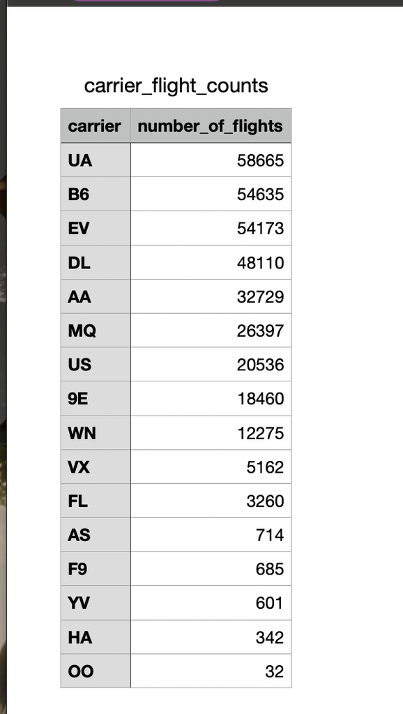